# Data Visualization Project 2

Alexander Jaenisch & Rafaela Neff

Beuth University of Applied Science Berlin

Summer Term 2018

# 1 Introduction

The repository can be found on [Github](https://github.com/amidisturbing/datavis2018).

## 1.1 The data

**Data source: https://data.louisvilleky.gov/dataset/animal-bites** (June 2018)

First we analyse our data and check its quality.

```
## [1] 19826    18
```

```
##  [1] "ID"                "bite_date"         "SpeciesIDDesc"
##  [4] "BreedIDDesc"       "GenderIDDesc"      "color"
##  [7] "vaccination_yrs"   "vaccination_date"  "victim_zip"
## [10] "AdvIssuedYNDesc"   "WhereBittenIDDesc" "quarantine_date"
## [13] "DispositionIDDesc" "head_sent_date"    "release_date"
## [16] "ResultsIDDesc"     "FollowupYNDesc"    "ResolveCompYesNo"
```

```
##                ID         bite_date     SpeciesIDDesc       BreedIDDesc
##                 0               732               240             11216
##      GenderIDDesc             color   vaccination_yrs  vaccination_date
##              5528              5548             11732             10840
##        victim_zip   AdvIssuedYNDesc WhereBittenIDDesc   quarantine_date
##              3700             14640              1362             15768
## DispositionIDDesc    head_sent_date      release_date     ResultsIDDesc
##             16756             18916             16080             16618
##    FollowupYNDesc  ResolveCompYesNo
##                 0             19826
```

Examining the data by hand, it appears that the column “bite_date” has some very old entries from the year 1952 where other animal breeds were likely to live in households then it may be the case today. The older the Date the less bites have been documented. It also held 2 impossible entries from the year 5013, which might be a typo meaning 2013.

## 1.2 Data preparation

The missing values of the dataset were converted to *NA*.

The values in “bite_date” were limited to the period between the 5th of May 1985 and the 21st of June 2018, to exclude the impossible dates.

# 2 Visualization

At first, we want to visualize the first five Species which are involved in Animal Bites in the given time period.

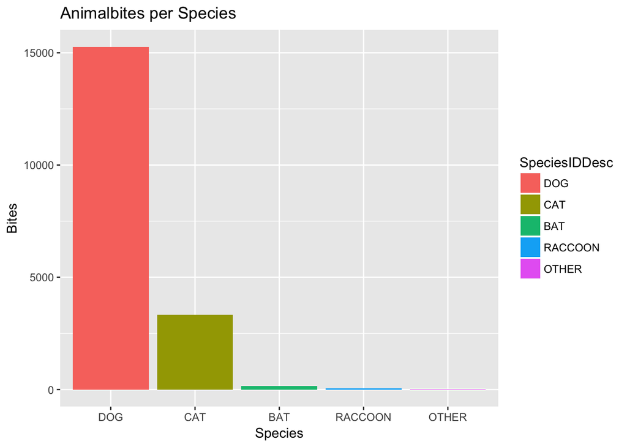

The plot shows that there were more than 15000 dogs, about 3500 cats, a few bats, raccoons and some other animals in the Top 5.

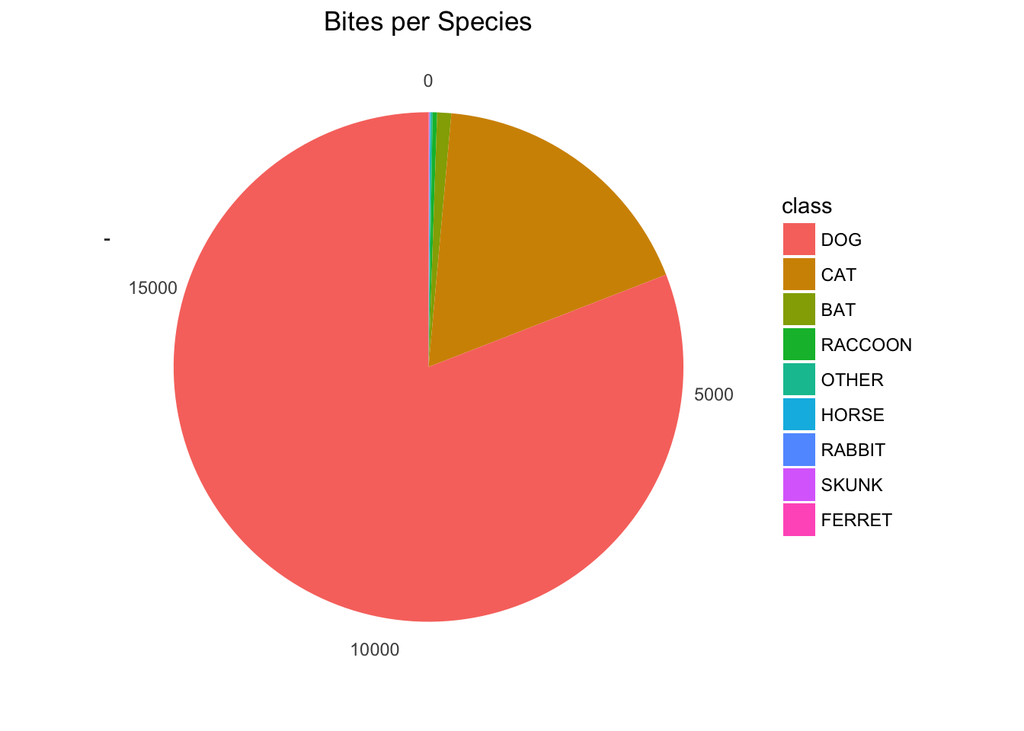

Since dogs are much more likely to be in contact with humans, this comes as no surprise. For our further Analysis, we will take a closer look at the data we have specifically about dog bites.

## 2.1 Dog Bites

We are most interested in the species that has the most available data.

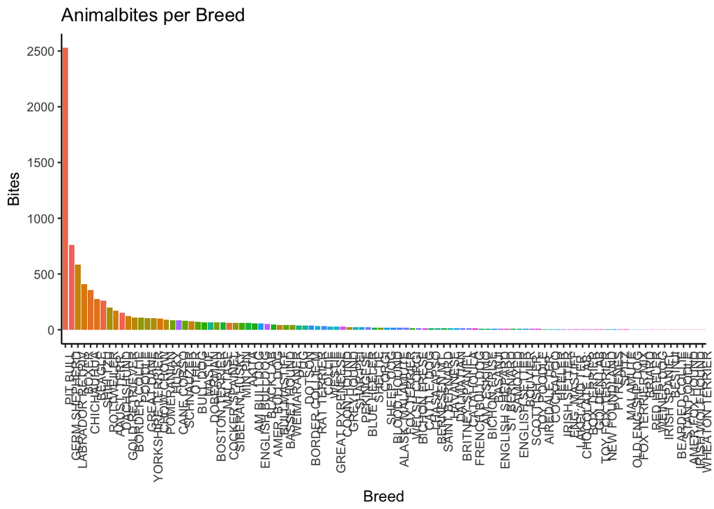

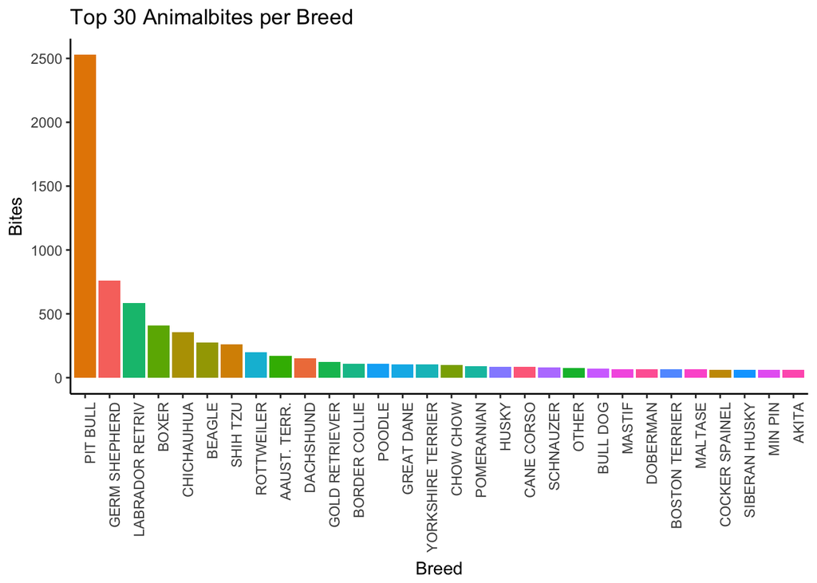

Visualizing the dog breeds of the animal bite dataset we clearly see, that pit bulls are on the very top of the ranking. It is important to keep in mind that serious bites are more likely to be reported.

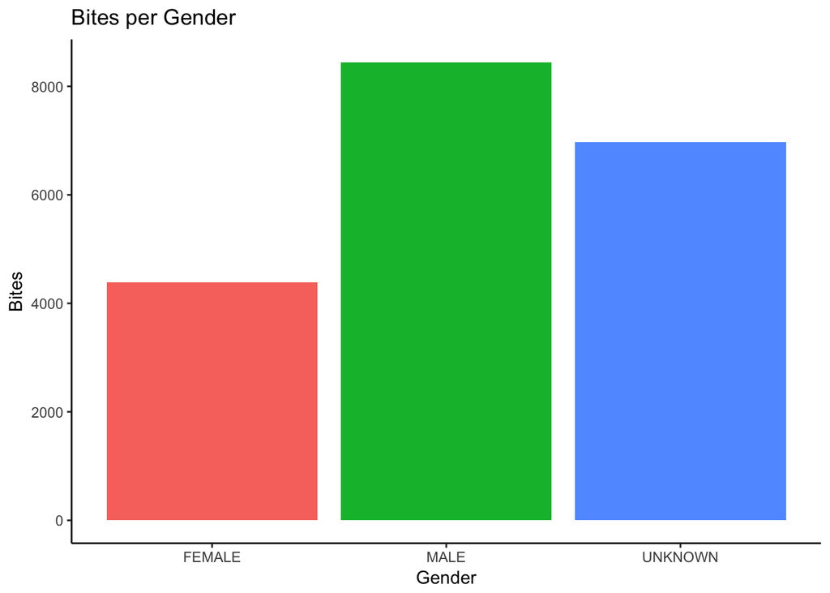

Twice as much male dogs are involved in biting accidents than female dogs.

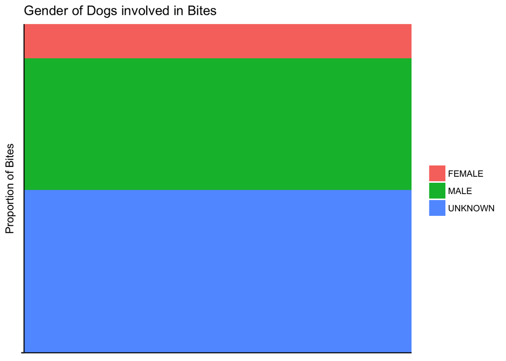

The proportion of dogs with unknown gender is significant.

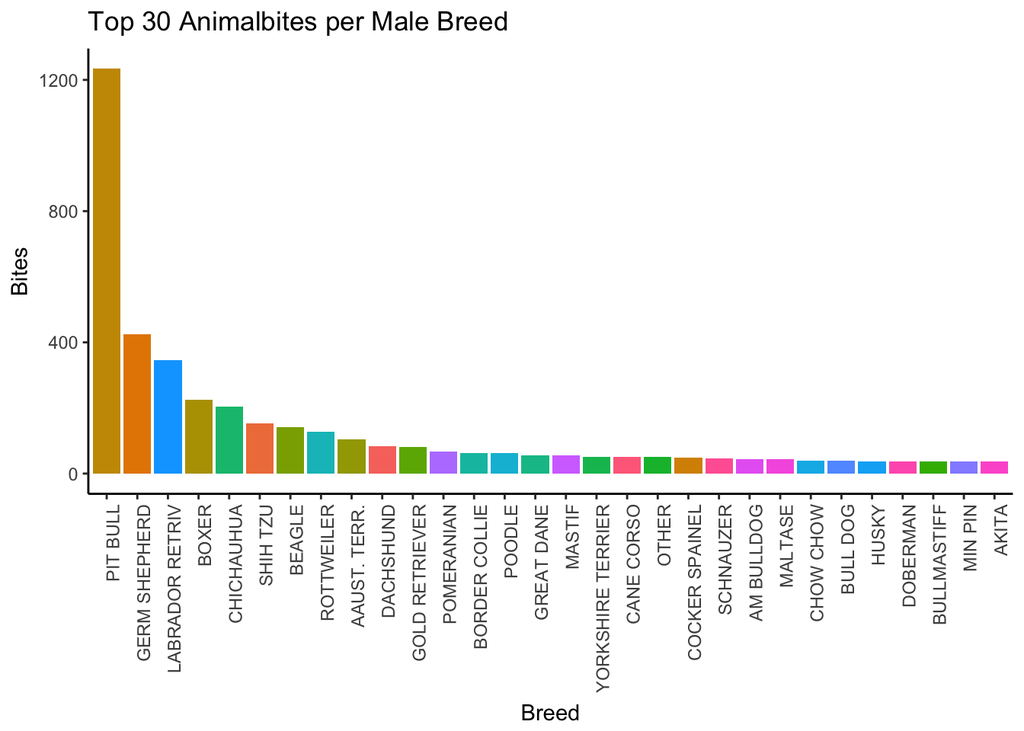

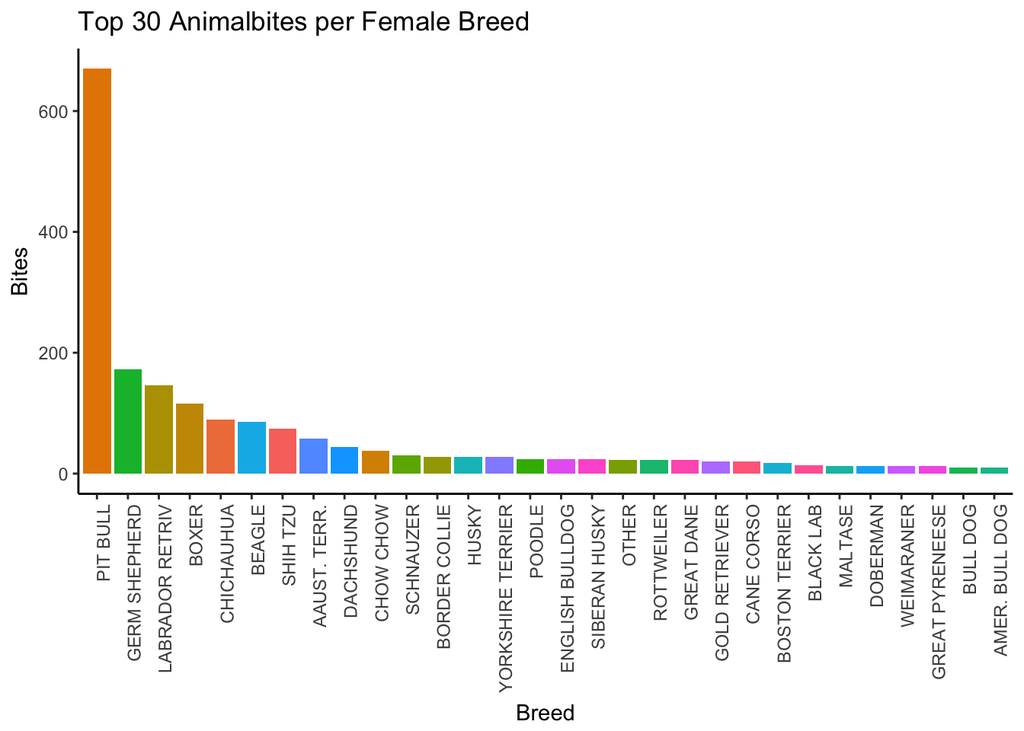

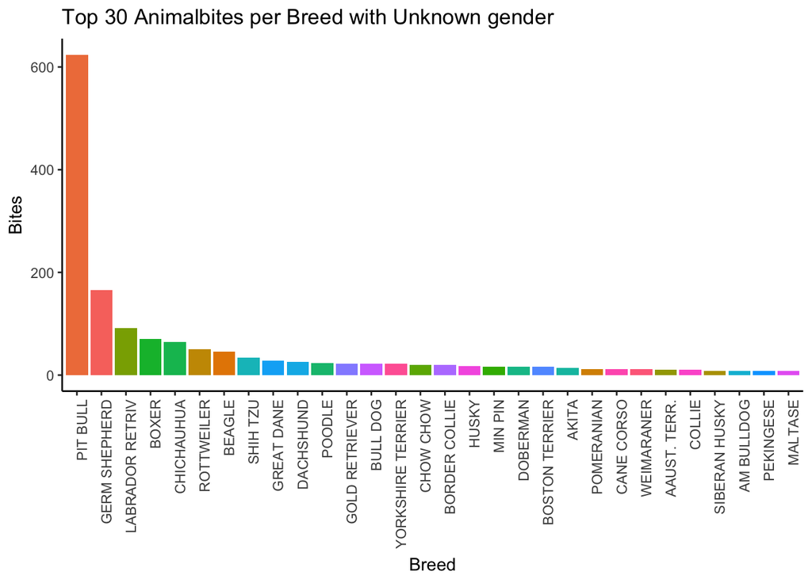

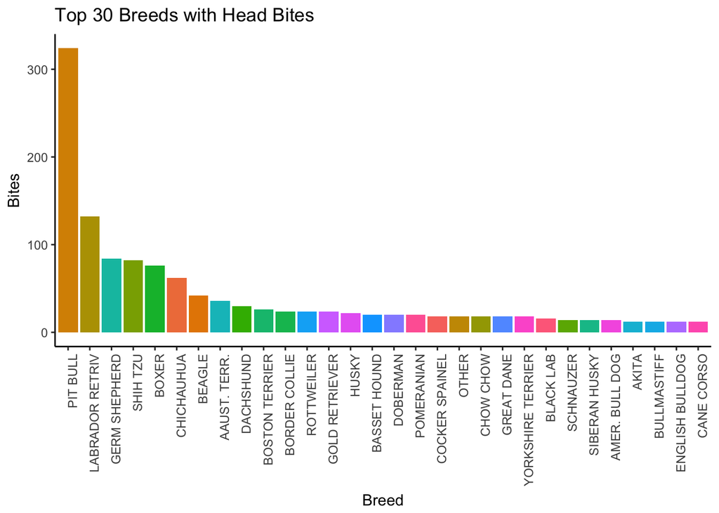

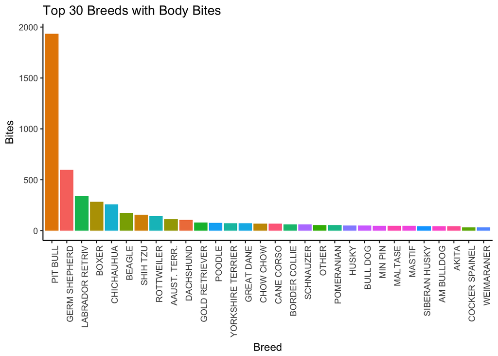

Dogs bite more often in the body because its easier to access.

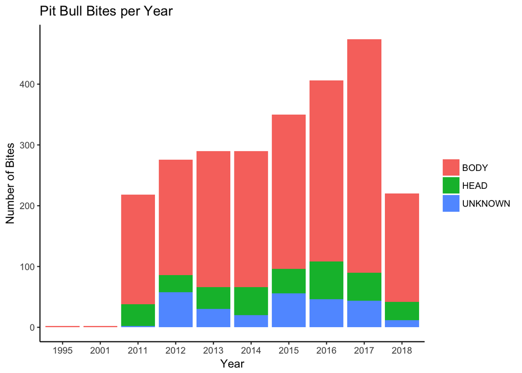

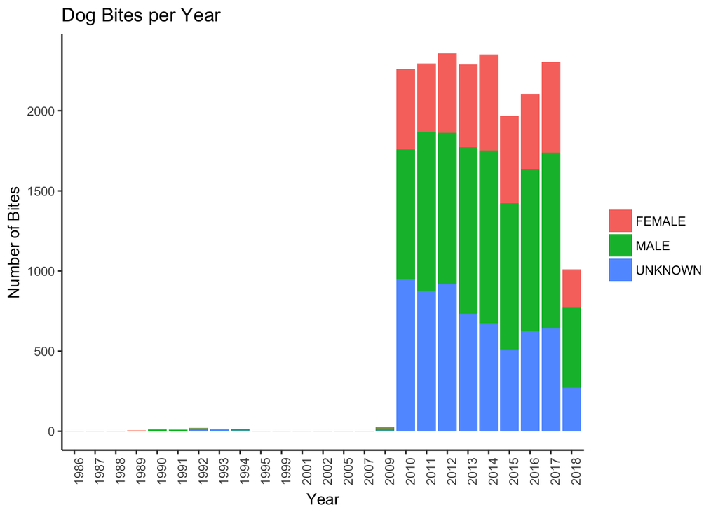

The most records in our dataset are from the period 2010 until 2017. Here we encounter around 2000 entries per year.

The fast growth of the archived reports could be due to the awareness of the importance of data as well as the fast development in the field of IT.

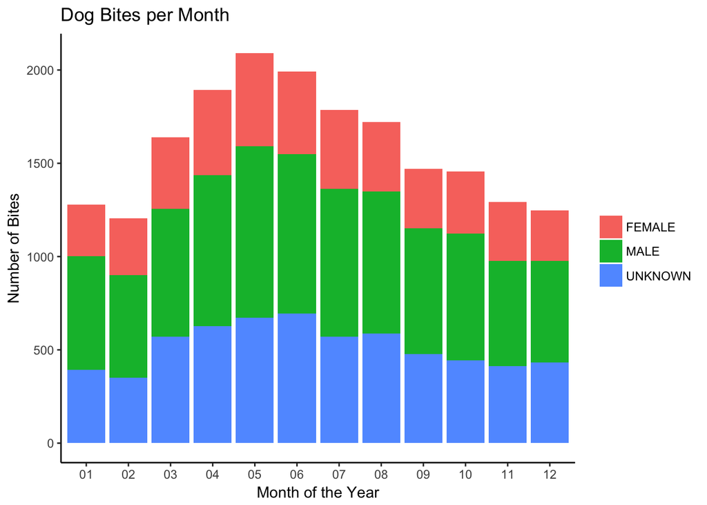

There are more dog bites reported in the warm months.

Since it is much more likely that dogs get in contact with strangers during the warmer months, the statistic seems to be quite reasonable. The chances of getting bitten by a dog are much higher if there are more unknown people around the animal. Also, the more dogs you meet, the higher your chances are to get bitten.

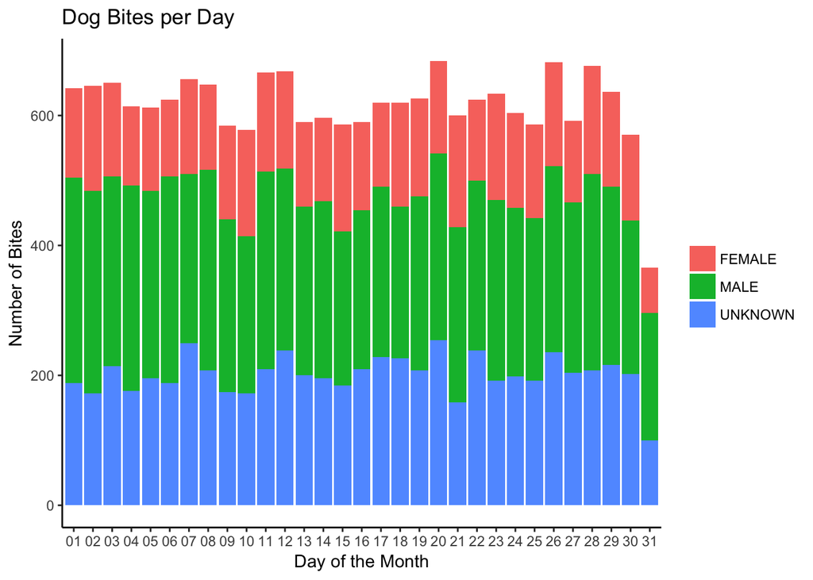

The day of the month has no influence on the number of reported dog bites.

The distribution of the gender of the recorded dogs that attacked someone stays equal during the investigated time intervals.

## 2.2 Cat Bites

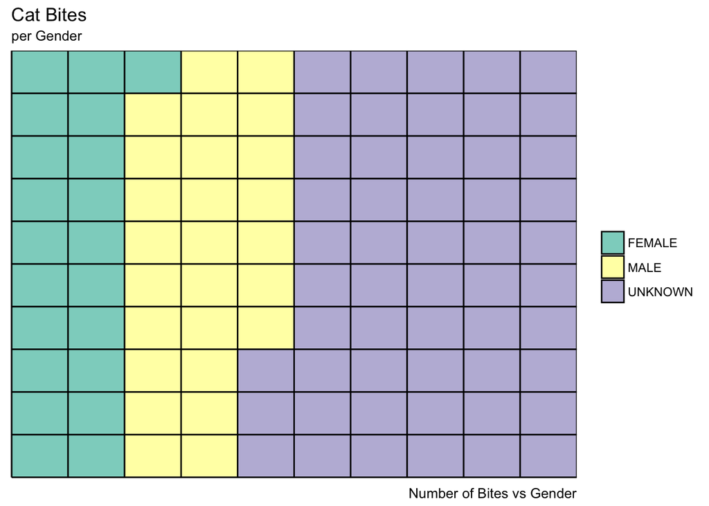

The gender stayed mostly unrecorded. There is a slightly higher amount of male cats in the records.

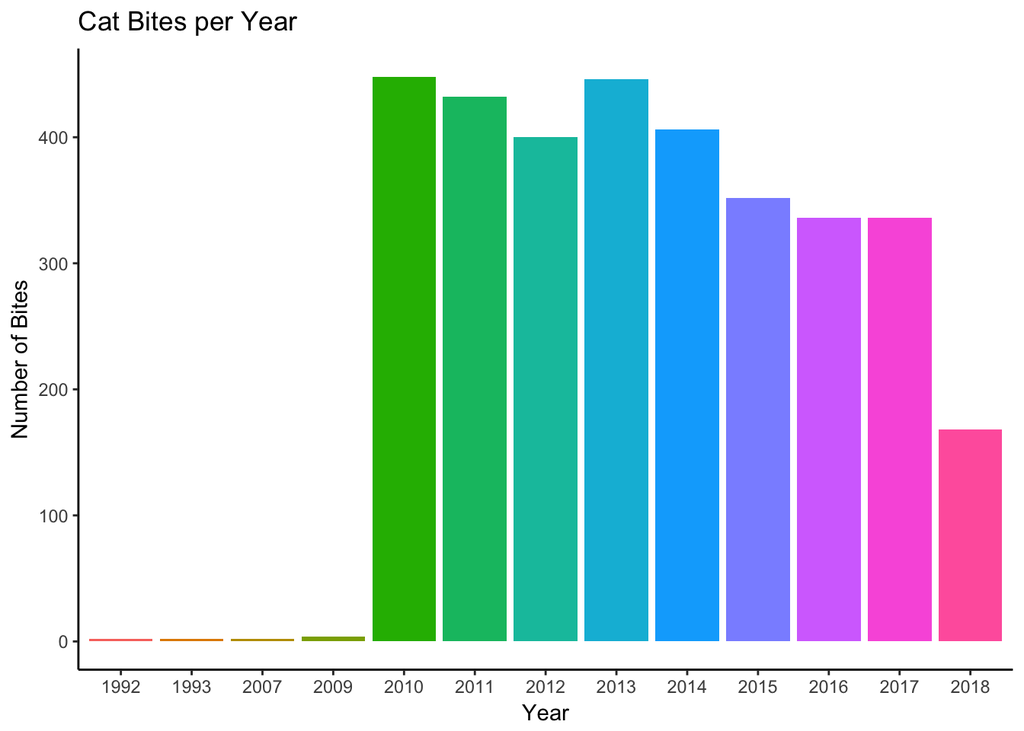

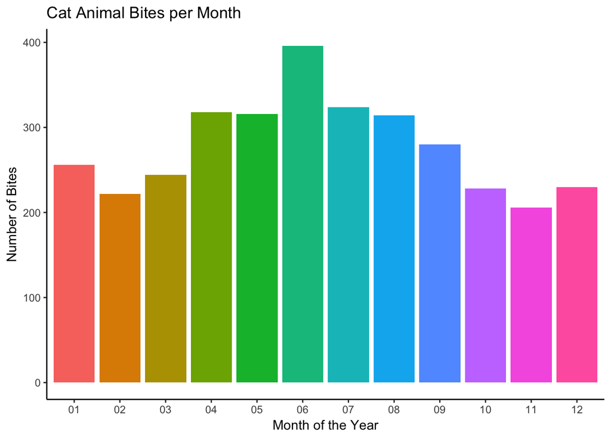

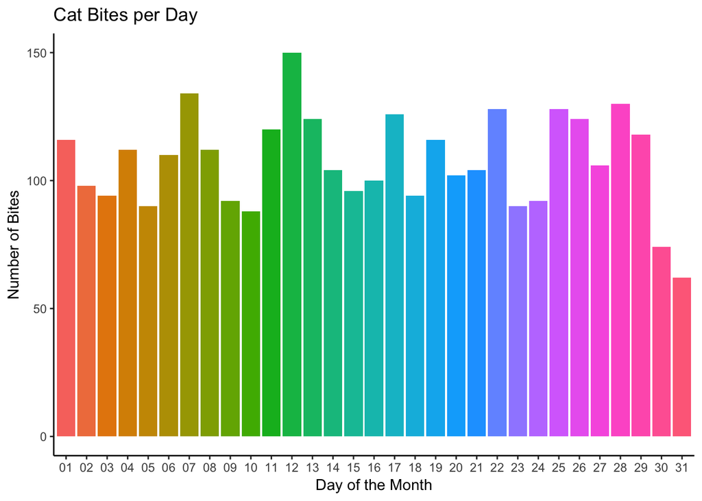

The results are similar to those about dog bites. The development in IT and Infrastructure could be a reason for the increase in the recorded bites per Year. We can also assume that the rise in the summer months is due to an increase in outdoor activity. There is not much difference in the number of reported bites per day of the month.

## 2.3 Other Species

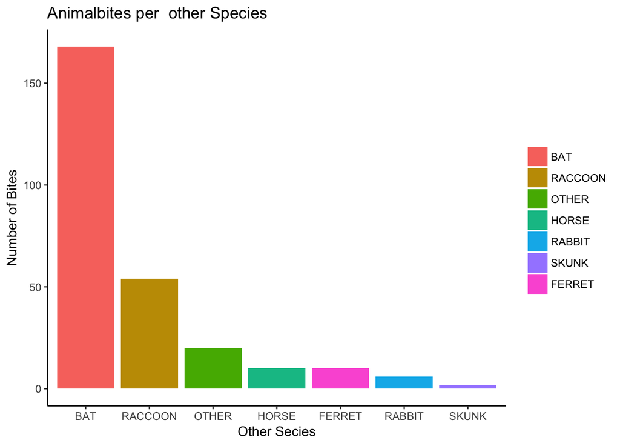

Bats are the most likely under the remaining reported species to bite humans.

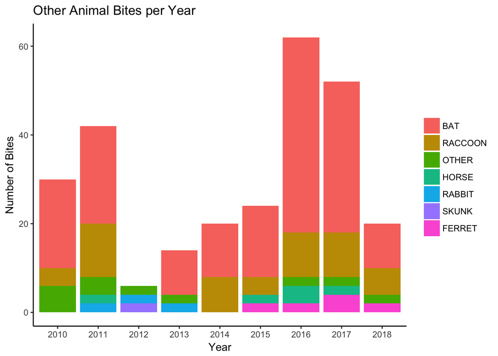

There is a rise in reported animal bites by the other species from 2016 on.

The numbers for 2018 are low since this Analysis is from June 2018, so the dataset can be seen as incomplete.

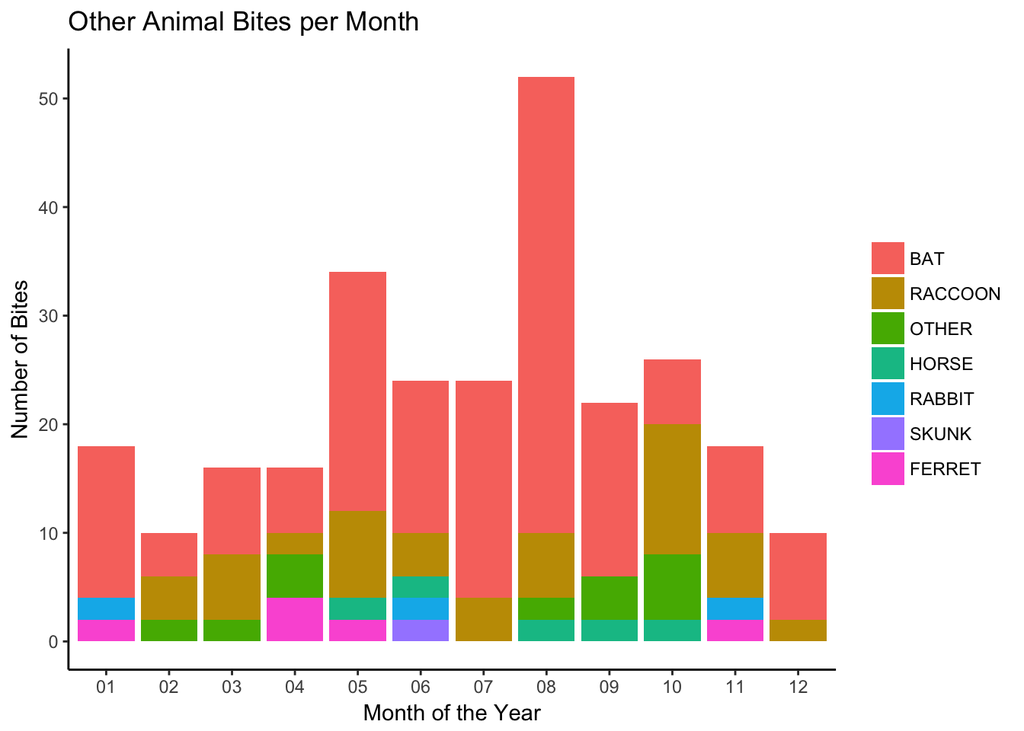

The reports show a rise in the months of May and August.

The highest rise in August can be explained by the fact, that most bats maternity season is ending in August. Especially if bats are removed from buildings during that season, the mothers try to find another way back in the building to get to their offspring.

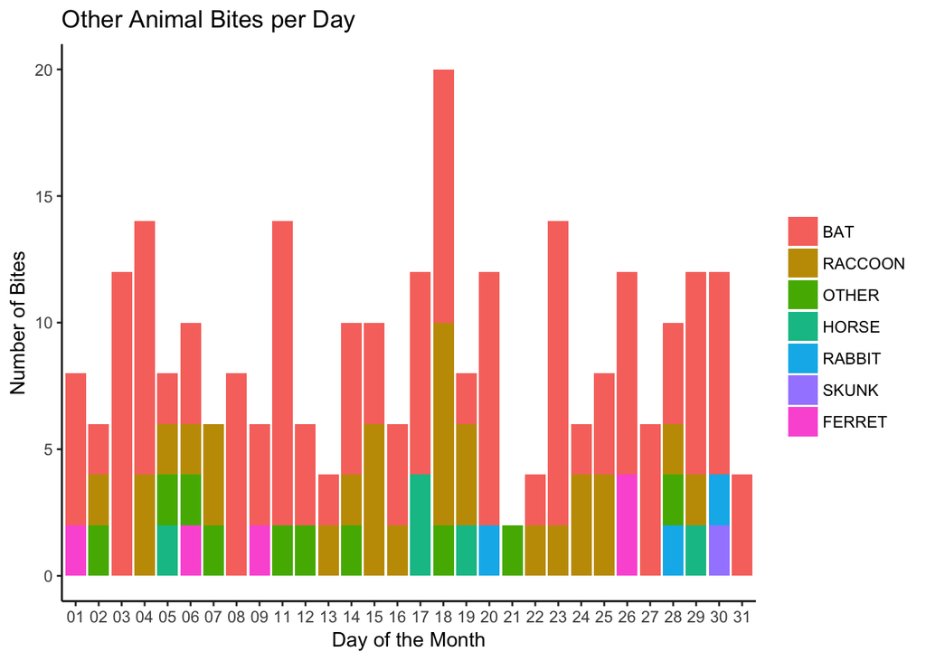

# 3 Conclusion

To analyse our visualizations we will add the opinion of Steffen Baldwin, expressed in his article *The Lies, Damn Lies and Statistics Behind Dog Bites*. The article was published in 2015 under the URL https://www.huffingtonpost.com/steffen-baldwin/the-lies-damn-lies-and-st_b_8112394.html.

By just looking at the charts it might seem obvious to conclude that Pitbulls are most likely to bite human beings, no matter of the gender of the dog, nor if the victim was bitten in head or body.

Now we will take into the account the earlier mentioned arguments of Steffen Baldwin. According to his article the questions

A, What is a Pit Bull?

and

B, How are pit bulls identified?

are answered as follows:

**What is a Pit Bull?:** It is commonly accepted that “pit bull” is not a breed but a loosely defined and general category. Definition of this category varies depending upon the source. Any blocky headed dog, or any mix of breeds that is between 35 and 100 pounds and upwards of 30 individual dog breeds may currently fall in this broad category through the use of visual breed identification.

**How are pit bulls identified?:** Visual breed identification, or the process of tilting your head 30 degrees to the right or left and guessing based on a few, basic traits and the inability to automatically identify the dog as something else, is how pit bulls are identified.

Since the most dogs living in American households are mixed breeds some dogs declared as pit bulls by visual breed identification could also genetically be another breed.

The rise of pit bulls as a breed being chosen to be a domestic animal in the last years could also be a bias to our data.